# Imports and other stuff

```python
!pip install scanpy
!pip install igraph
!pip install leidenalg
```

```
     ━━━━━━━━━━━━━━━━━━━━━━━━━━━━━━━━━━━━━━━━ 2.1/2.1 MB 7.1 MB/s eta 0:00:00
     ━━━━━━━━━━━━━━━━━━━━━━━━━━━━━━━━━━━━━━━━ 122.4/122.4 kB 6.2 MB/s eta 0:00:00
     ━━━━━━━━━━━━━━━━━━━━━━━━━━━━━━━━━━━━━━━━ 56.8/56.8 kB 5.5 MB/s eta 0:00:00
  Preparing metadata (setup.py) ... done
     ━━━━━━━━━━━━━━━━━━━━━━━━━━━━━━━━━━━━━━━━ 85.7/85.7 kB 8.6 MB/s eta 0:00:00
     ━━━━━━━━━━━━━━━━━━━━━━━━━━━━━━━━━━━━━━━━ 79.8/79.8 kB 4.0 MB/s eta 0:00:00
     ━━━━━━━━━━━━━━━━━━━━━━━━━━━━━━━━━━━━━━━━ 3.3/3.3 MB 10.2 MB/s eta 0:00:00
     ━━━━━━━━━━━━━━━━━━━━━━━━━━━━━━━━━━━━━━━━ 2.0/2.0 MB 7.4 MB/s eta 0:00:00
```

```python
# IMPORTANT: RUN THIS CELL IN ORDER TO IMPORT YOUR KAGGLE DATA SOURCES
# TO THE CORRECT LOCATION (/kaggle/input) IN YOUR NOTEBOOK,
# THEN FEEL FREE TO DELETE THIS CELL.
# NOTE: THIS NOTEBOOK ENVIRONMENT DIFFERS FROM KAGGLE'S PYTHON
# ENVIRONMENT SO THERE MAY BE MISSING LIBRARIES USED BY YOUR
# NOTEBOOK.

import os
import sys
from tempfile import NamedTemporaryFile
from urllib.request import urlopen
from urllib.parse import unquote, urlparse
from urllib.error import HTTPError
from zipfile import ZipFile
import tarfile
import shutil

CHUNK_SIZE = 40960
DATA_SOURCE_MAPPING = 'citeseq-scrnaseq-proteins-human-pbmcs-2019:https%3A%2F%2Fstorage.googleapis.com%2Fkaggle-data-sets%2F2471423%2F4190039%2Fbundle%2Farchive.zip%3FX-Goog-Algorithm%3DGOOG4-RSA-SHA256%26X-Goog-Credential%3Dgcp-kaggle-com%2540kaggle-161607.iam.gserviceaccount.com%252F20240428%252Fauto%252Fstorage%252Fgoog4_request%26X-Goog-Date%3D20240428T141433Z%26X-Goog-Expires%3D259200%26X-Goog-SignedHeaders%3Dhost%26X-Goog-Signature%3D1051638796ffb6615cb05812aaf4c1b6e3a1f4269c333a641d2804668a…'

KAGGLE_INPUT_PATH='/kaggle/input'
KAGGLE_WORKING_PATH='/kaggle/working'
KAGGLE_SYMLINK='kaggle'

!umount /kaggle/input/ 2> /dev/null
shutil.rmtree('/kaggle/input', ignore_errors=True)
os.makedirs(KAGGLE_INPUT_PATH, 0o777, exist_ok=True)
os.makedirs(KAGGLE_WORKING_PATH, 0o777, exist_ok=True)

try:
  os.symlink(KAGGLE_INPUT_PATH, os.path.join("..", 'input'), target_is_directory=True)
except FileExistsError:
  pass
try:
  os.symlink(KAGGLE_WORKING_PATH, os.path.join("..", 'working'), target_is_directory=True)
except FileExistsError:
  pass

for data_source_mapping in DATA_SOURCE_MAPPING.split(','):
    directory, download_url_encoded = data_source_mapping.split(':')
    download_url = unquote(download_url_encoded)
    filename = urlparse(download_url).path
    destination_path = os.path.join(KAGGLE_INPUT_PATH, directory)
    try:
        with urlopen(download_url) as fileres, NamedTemporaryFile() as tfile:
            total_length = fileres.headers['content-length']
            print(f'Downloading {directory}, {total_length} bytes compressed')
            dl = 0
            data = fileres.read(CHUNK_SIZE)
            while len(data) > 0:
                dl += len(data)
                tfile.write(data)
                done = int(50 * dl / int(total_length))
                sys.stdout.write(f"\r[{'=' * done}{' ' * (50-done)}] {dl} bytes downloaded")
                sys.stdout.flush()
                data = fileres.read(CHUNK_SIZE)
            if filename.endswith('.zip'):
              with ZipFile(tfile) as zfile:
                zfile.extractall(destination_path)
            else:
              with tarfile.open(tfile.name) as tarfile:
                tarfile.extractall(destination_path)
            print(f'\nDownloaded and uncompressed: {directory}')
    except HTTPError as e:
        print(f'Failed to load (likely expired) {download_url} to path {destination_path}')
        continue
    except OSError as e:
        print(f'Failed to load {download_url} to path {destination_path}')
        continue

print('Data source import complete.')
```

```
Downloading citeseq-scrnaseq-proteins-human-pbmcs-2019, 44334628 bytes compressed
[==================================================] 44334628 bytes downloaded
Downloaded and uncompressed: citeseq-scrnaseq-proteins-human-pbmcs-2019
Data source import complete.
```

```python
# This Python 3 environment comes with many helpful analytics libraries installed
# It is defined by the kaggle/python Docker image: https://github.com/kaggle/docker-python
# For example, here's several helpful packages to load

import numpy as np # linear algebra
import pandas as pd # data processing, CSV file I/O (e.g. pd.read_csv)

# Input data files are available in the read-only "../input/" directory
# For example, running this (by clicking run or pressing Shift+Enter) will list all files under the input directory

import os
for dirname, _, filenames in os.walk('/kaggle/input'):
    for filename in filenames:
        print(os.path.join(dirname, filename))

# You can write up to 20GB to the current directory (/kaggle/working/) that gets preserved as output when you create a version using "Save & Run All"
# You can also write temporary files to /kaggle/temp/, but they won't be saved outside of the current session
```

```
/kaggle/input/citeseq-scrnaseq-proteins-human-pbmcs-2019/GSM3681520_MNC_HTO_counts.tsv/citeseq_hto_counts.tsv
/kaggle/input/citeseq-scrnaseq-proteins-human-pbmcs-2019/GSM3681521_MNC_BULK_RNA.tsv/bulk_RNA.tsv
/kaggle/input/citeseq-scrnaseq-proteins-human-pbmcs-2019/GSM3681518_MNC_RNA_counts.tsv/citeseq_rna_counts.tsv
/kaggle/input/citeseq-scrnaseq-proteins-human-pbmcs-2019/GSM3681519_MNC_ADT_counts.tsv/citeseq_adt_counts.tsv
```

```python
import scanpy as sc
from scipy.stats import median_abs_deviation
import matplotlib.pyplot as pl
import seaborn as sns
```

```python
sc.settings.verbosity = 3  # verbosity: errors (0), warnings (1), info (2), hints (3)
sc.logging.print_header()
```

```
scanpy==1.10.1 anndata==0.10.7 umap==0.5.6 numpy==1.25.2 scipy==1.11.4 pandas==2.0.3 scikit-learn==1.2.2 statsmodels==0.14.2 igraph==0.11.4 pynndescent==0.5.12
```

# Analysis

## Reading the data

Reading the data. We need to transpose the table to make sure that rows (observations) contain cells and columns (variables) contain genes

```python
adata = sc.read_csv(
    '/kaggle/input/citeseq-scrnaseq-proteins-human-pbmcs-2019/GSM3681518_MNC_RNA_counts.tsv/citeseq_rna_counts.tsv',
    delimiter="\t",
)
adata = adata.T
adata
```

```
AnnData object with n_obs × n_vars = 33454 × 17009
```

## Quality control

```python
print("Cells at start:", adata.shape[0])

#Basic filtering of genes and cells
sc.pp.filter_cells(adata, min_genes=200)
sc.pp.filter_genes(adata, min_cells=20)
```

```
Cells at start: 33454
filtered out 6 cells that have less than 200 genes expressed
filtered out 1385 genes that are detected in less than 20 cells
```

**First, we gonna filter low-quality cells**

```python
# mitochondrial genes
adata.var["mt"] = adata.var_names.str.startswith("MT-")
# ribosomal genes
adata.var["ribo"] = adata.var_names.str.startswith(("RPS", "RPL"))
# hemoglobin genes.
adata.var["hb"] = adata.var_names.str.contains(("^HB[^(P)]"))
```

```python
#We calculate statistics to found outliers

sc.pp.calculate_qc_metrics(
    adata, qc_vars=["mt", "ribo", "hb"], inplace=True, percent_top=[20], log1p=True
)
```

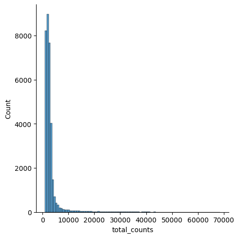

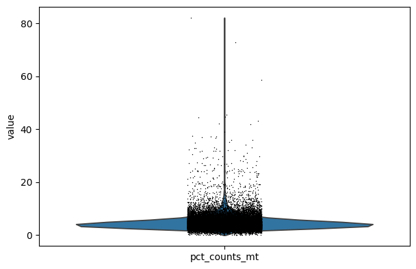

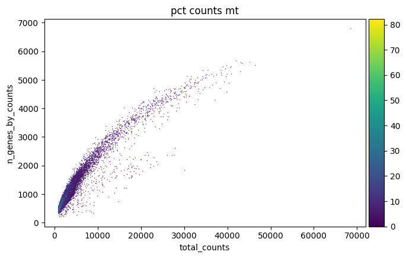

```python
p1 = sns.displot(adata.obs["total_counts"], bins=100, kde=False)
p2 = sc.pl.violin(adata, "pct_counts_mt")
p3 = sc.pl.scatter(adata, "total_counts", "n_genes_by_counts", color="pct_counts_mt")
```

Some cells seem to have many MT-genes.

```python
def is_outlier(adata, metric: str, nmads: int):
    M = adata.obs[metric]
    outlier = (M < np.median(M) - nmads * median_abs_deviation(M)) | (
        np.median(M) + nmads * median_abs_deviation(M) < M
    )
    return outlier
```

**Filtering all outliers:**

```python
adata.obs["outlier"] = (
    is_outlier(adata, "log1p_total_counts", 5)
    | is_outlier(adata, "log1p_n_genes_by_counts", 5)
    | is_outlier(adata, "pct_counts_in_top_20_genes", 5)
)
adata.obs.outlier.value_counts()
```

```
outlier
False    31839
True      1609
Name: count, dtype: int64
```

**Additional filtering of mitochondrial outliers (cells with >8% mt counts):**

```python
adata.obs["mt_outlier"] = is_outlier(adata, "pct_counts_mt", 3) | (
    adata.obs["pct_counts_mt"] > 8
)
adata.obs.mt_outlier.value_counts()
```

```
mt_outlier
False    30467
True      2981
Name: count, dtype: int64
```

```python
print(f"Total number of cells: {adata.n_obs}")
adata = adata[(~adata.obs.outlier) & (~adata.obs.mt_outlier)].copy()
print(f"Number of cells after filtering of low quality cells: {adata.n_obs}")
```

```
Total number of cells: 33448
Number of cells after filtering of low quality cells: 29038
```

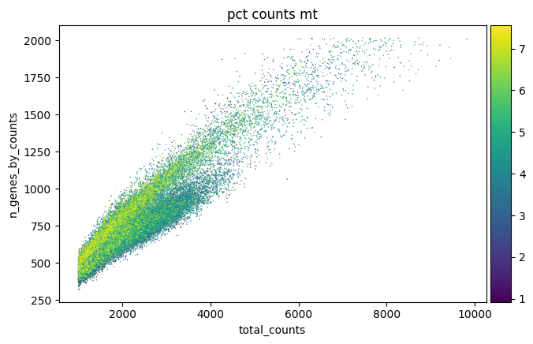

```python
p1 = sc.pl.scatter(adata, "total_counts", "n_genes_by_counts", color="pct_counts_mt")
```

**We started with 33454 cells and ended up with 29038**

## Normalization

**Total-count normalization:**

```python
sc.pp.normalize_total(adata, target_sum=1e4)
```

```
normalizing counts per cell
    finished (0:00:00)
```

**Logarithmization:**

```python
sc.pp.log1p(adata)
```

## Feature selection

**Visualising highly variable genes:**

```python
sc.pp.highly_variable_genes(adata, min_mean=0.0125, max_mean=3, min_disp=0.5)
```

```
extracting highly variable genes
    finished (0:00:05)
--> added
    'highly_variable', boolean vector (adata.var)
    'means', float vector (adata.var)
    'dispersions', float vector (adata.var)
    'dispersions_norm', float vector (adata.var)
```

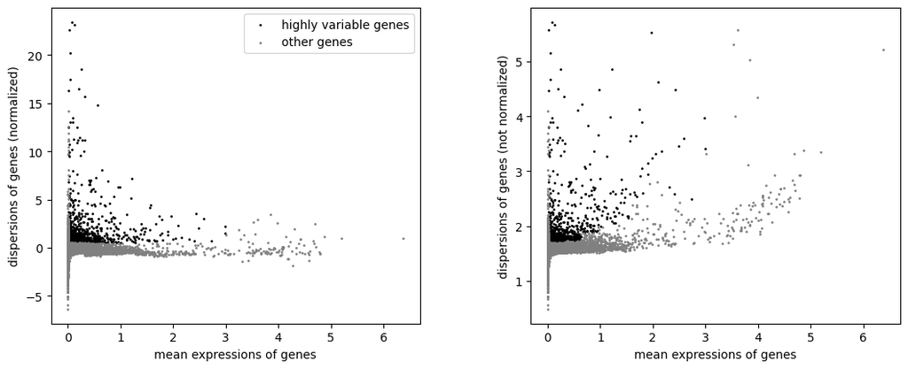

```python
sc.pl.highly_variable_genes(adata)
```

```python
adata.raw = adata
```

**Filtering:**

```python
adata = adata[:, adata.var.highly_variable]
```

**Regression and scaling of the data:**

```python
sc.pp.regress_out(adata, ["total_counts", "pct_counts_mt"])
```

```
regressing out ['total_counts', 'pct_counts_mt']
```

```
    finished (0:00:46)
```

```python
sc.pp.scale(adata, max_value=10)
```

## PCA-analysis

```python
sc.tl.pca(adata, svd_solver="arpack")
```

```
computing PCA
    with n_comps=50
    finished (0:00:24)
```

**PCA-plot:**

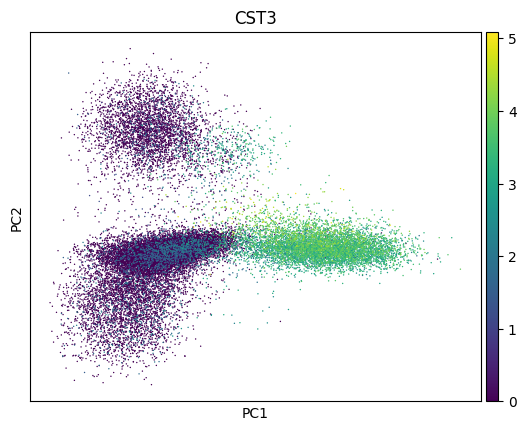

```python
sc.pl.pca(adata, color="CST3")
```

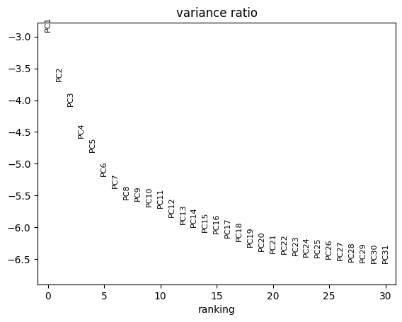

```python
sc.pl.pca_variance_ratio(adata, log=True)
```

## UMAP

```python
sc.pp.neighbors(adata, n_neighbors=15, n_pcs=40)
```

```
computing neighbors
    using 'X_pca' with n_pcs = 40
    finished: added to `.uns['neighbors']`
    `.obsp['distances']`, distances for each pair of neighbors
    `.obsp['connectivities']`, weighted adjacency matrix (0:00:52)
```

```python
sc.tl.leiden(
    adata,
    resolution=0.2,
    random_state=0,
    flavor="igraph",
    n_iterations=2,
    directed=False,
)
sc.tl.paga(adata)
sc.pl.paga(adata, plot=False)
sc.tl.umap(adata, init_pos='paga')
```

```
running Leiden clustering
    finished: found 8 clusters and added
    'leiden', the cluster labels (adata.obs, categorical) (0:00:02)
running PAGA
    finished: added
    'paga/connectivities', connectivities adjacency (adata.uns)
    'paga/connectivities_tree', connectivities subtree (adata.uns) (0:00:00)
--> added 'pos', the PAGA positions (adata.uns['paga'])
computing UMAP
    finished: added
    'X_umap', UMAP coordinates (adata.obsm) (0:00:24)
```

```python
sc.tl.umap(adata)
```

```
computing UMAP
    finished: added
    'X_umap', UMAP coordinates (adata.obsm) (0:00:27)
```

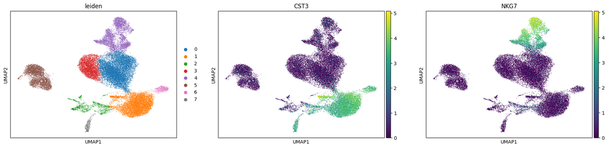

```python
sc.pl.umap(adata, color=["leiden", "CST3", "NKG7"])
```

**In total we got 8 clusters.**

## Annotation

```
ranking genes
    finished: added to `.uns['rank_genes_groups']`
    'names', sorted np.recarray to be indexed by group ids
    'scores', sorted np.recarray to be indexed by group ids
    'logfoldchanges', sorted np.recarray to be indexed by group ids
    'pvals', sorted np.recarray to be indexed by group ids
    'pvals_adj', sorted np.recarray to be indexed by group ids (0:00:24)
```

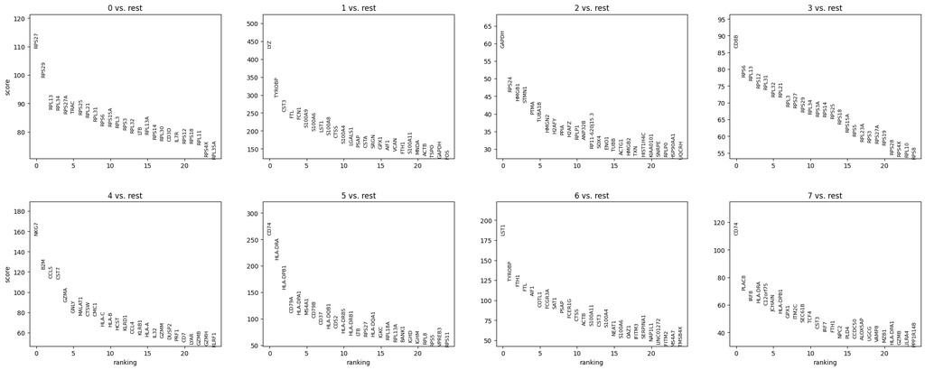

```python
sc.tl.rank_genes_groups(adata, "leiden", method="t-test")
sc.pl.rank_genes_groups(adata, n_genes=25, sharey=False)
```

```
ranking genes
    finished (0:02:19)
```

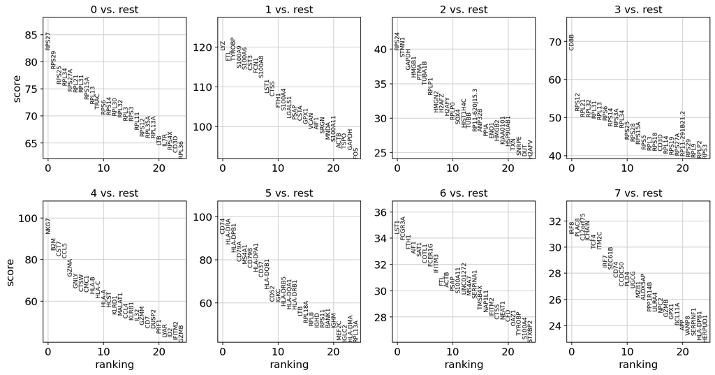

```python
sc.tl.rank_genes_groups(adata, "leiden", method="wilcoxon")
sc.pl.rank_genes_groups(adata, n_genes=25, sharey=False)
```

```
ranking genes
    finished (0:44:46)
```

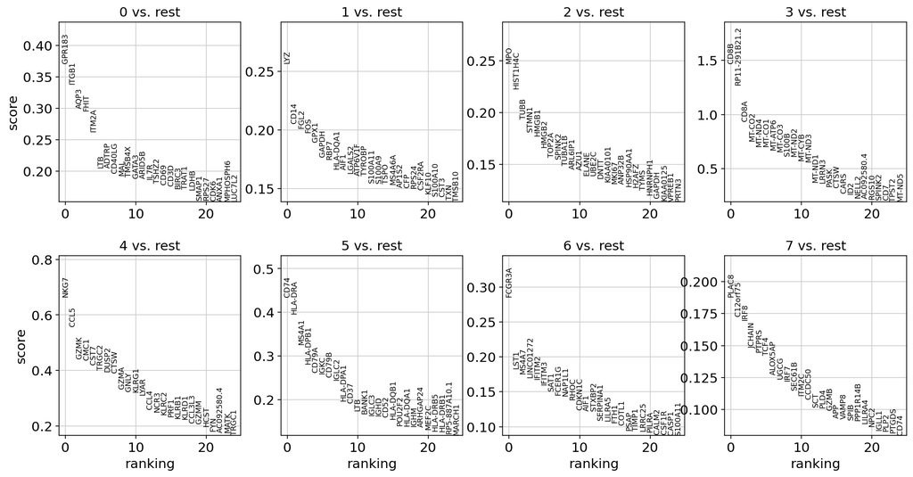

```python
sc.tl.rank_genes_groups(adata, "leiden", method="logreg", max_iter=1000)
sc.pl.rank_genes_groups(adata, n_genes=25, sharey=False)
```

## Define cell types

We start looking for reliable cell markers based on several publications (https://www.ncbi.nlm.nih.gov/pmc/articles/PMC8494216/, https://pubmed.ncbi.nlm.nih.gov/30266715/).

While most clusters exhibit distinct cell types like B-cells and CD8 T-cells, one group stands out due to its elevated expression of proliferation-related genes such as STMN1, TOP2A, and KIAA0101. Additionally, its distribution on the UMAP plot appears scattered and indistinct, with sparse dots scattered across various locations. Consequently, we concluded that this cluster may represent different subpopulations of stem cells, which are found in the bone marrow and play a crucial role in generating all other cell types.

| Cluster idx | Cell type | Markers |
| --- | --- | --- |
| 0 | CD4 T cells | IL7R |
| 1 | CD14+ Monocytes | CD14, LYZ |
| 2 | Hematopoietic stem cells (?) | STMN1, TOP2A, KIAA0101, DNTT, UBE2C, SOX4 |
| 3 | CD8 T cells | CD8A, CD8B |
| 4 | NK cells | GNLY, NKG7 |
| 5 | B cells | MS4A1, CD37, CD79A |
| 6 | FCGR3A+ Monocytes | FCGR3A, MS4A7 |
| 7 | Dendritic Cells | IRF8, TCF4, CST3, SPIB |

```python
new_cluster_names = [
    "CD4 T",
    "CD14+ Monocytes",
    "Stem cells",
    "CD8 T",
    "NK",
    "B-cells",
    "FCGR3A+ Monocytes",
    "Dendritic",
]
adata.rename_categories("leiden", new_cluster_names)
```

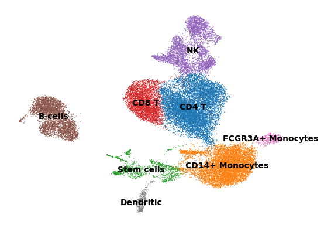

```python
sc.pl.umap(
    adata, color="leiden", legend_loc="on data", title="", frameon=False
)
```

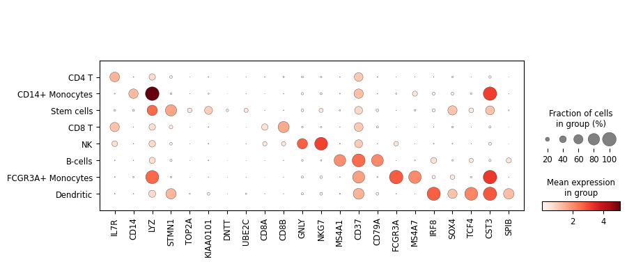

```python
marker_genes = ["IL7R", "CD14", "LYZ", "STMN1", "TOP2A", "KIAA0101", "DNTT", "UBE2C", "CD8A", "CD8B", "GNLY", "NKG7", "MS4A1", "CD37", "CD79A", "FCGR3A", "MS4A7", "IRF8", "SOX4", "TCF4", "CST3", "SPIB"]
sc.pl.dotplot(adata, marker_genes, groupby="leiden")
```